# Prediction Assignment Writeup

## Project summary

> Background:  
> Using devices such as Jawbone Up, Nike FuelBand, and Fitbit it is now possible to collect a large amount of data about personal activity relatively inexpensively. These type of devices are part of the quantified self movement – a group of enthusiasts who take measurements about themselves regularly to improve their health, to find patterns in their behavior, or because they are tech geeks. One thing that people regularly do is quantify how much of a particular activity they do, but they rarely quantify how well they do it. In this project, your goal will be to use data from accelerometers on the belt, forearm, arm, and dumbell of 6 participants. They were asked to perform barbell lifts correctly and incorrectly in 5 different ways. More information is available from the website here: http://groupware.les.inf.puc-rio.br/har (see the section on the Weight Lifting Exercise Dataset).

> Data: The training data for this project are available here: https://d396qusza40orc.cloudfront.net/predmachlearn/pml-training.csv The test data are available here: https://d396qusza40orc.cloudfront.net/predmachlearn/pml-testing.csv The data for this project come from this source: http://groupware.les.inf.puc-rio.br/har. If you use the document you create for this class for any purpose please cite them as they have been very generous in allowing their data to be used for this kind of assignment.

## Data cleaning and preprocessing

```r
# Load data
setwd("~/ayman/master/home/khodieaf/ayman/lrnngprog/R_resources/Coursera_DataScience/ML")
dat  = read.csv("pml-training.csv", header = T, na.strings = c("", "#DIV/0!", "NA"))[, -c(1:7)] # keep activity related vars only
unk = read.csv("pml-testing.csv", header = T, na.strings = c("", "#DIV/0!", "NA"))[, -c(1:7)]  # keep activity related vars only

# data cleaning and preprocesing
rmcol = as.vector(!is.na(apply(unk,2,sd))) # remove columns with NAs
dat   = dat[,rmcol]
unk   = unk[,rmcol]

# convert input vars into numeric class
ind   = c(1:52)
dat[, c(1:52)]  = as.data.frame(lapply(dat[,ind], as.numeric))
unk[, c(1:52)] = as.data.frame(lapply(unk[,ind], as.numeric))
```

## Data partitioning

```r
# Load packages
library(caret)
library(rattle)

# Partition for building a model ensemble using the best 2 performing models; the rest for validation
inbuild = createDataPartition(dat$classe, p=0.75, list = F)
build   = dat[inbuild,]
val     = dat[-inbuild,]

# Partition the build data set into training and testing data sets
intrain  = createDataPartition(build$classe, p=0.75, list = F)
training = build[intrain,]
testing  = build[-intrain,]

dim(dat)
```

```
## [1] 19622    53
```

```r
dim(val)
```

```
## [1] 4904   53
```

```r
dim(build)
```

```
## [1] 14718    53
```

```r
dim(training)
```

```
## [1] 11040    53
```

```r
dim(testing)
```

```
## [1] 3678   53
```

## Cross validation parameters (Train control)

#### How cross validation was used?

repeated *K*-fold cross validation with 10 folds and repeated 10 times.

```r
ctrl = trainControl(method = "repeatedcv",                # repeated K-folds
                    number = 10,                          # 10 folds
                    repeats = 10,                         # 10 repeats
                    summaryFunction = multiClassSummary,  # Evaluate Performance
                    classProbs = T,                       # Estimate class probabilities
                    savePredictions = T)
```

## Models Training

A number of models will be assessed and the best 2 models will be used for ensembling.

### 1. Recursive partioning

```r
library(doMC)                                             # multi-core processing
registerDoMC(cores = 6)

set.seed(1234)
rpfit = train(classe ~ ., data = training, method = "rpart", trControl = ctrl)
```

[figure not shown]

```r
fancyRpartPlot(rpfit$finalModel, main = "Recursive partitioning tree")
```

#### Confusion Matrix

```r
rpart.pred = predict(rpfit, testing)
confusionMatrix(rpart.pred, testing$classe)
```

```
## Confusion Matrix and Statistics
##
##           Reference
## Prediction   A   B   C   D   E
##          A 617 106  19  34   6
##          B 113 413  28  83 155
##          C 221 151 495 319 153
##          D  93  42  99 167  48
##          E   2   0   0   0 314
##
## Overall Statistics
##
##                Accuracy : 0.5454
##                  95% CI : (0.5291, 0.5616)
##     No Information Rate : 0.2844
##     P-Value [Acc > NIR] : < 2.2e-16
##
##                   Kappa : 0.4308
##  Mcnemar's Test P-Value : < 2.2e-16
##
## Statistics by Class:
##
##                      Class: A Class: B Class: C Class: D Class: E
## Sensitivity            0.5899   0.5801   0.7722  0.27695  0.46450
## Specificity            0.9373   0.8722   0.7221  0.90829  0.99933
## Pos Pred Value         0.7890   0.5215   0.3697  0.37194  0.99367
## Neg Pred Value         0.8519   0.8964   0.9376  0.86497  0.89233
## Prevalence             0.2844   0.1936   0.1743  0.16395  0.18380
## Detection Rate         0.1678   0.1123   0.1346  0.04541  0.08537
## Detection Prevalence   0.2126   0.2153   0.3641  0.12208  0.08592
## Balanced Accuracy      0.7636   0.7261   0.7472  0.59262  0.73192
```

### 2. Random forests

```r
library(doMC)                                             # multi-core processing
registerDoMC(cores = 6)

set.seed(1234)
rffit = train(classe ~ ., data = training, method = "rf", trControl = ctrl)
```

#### Contributing vars

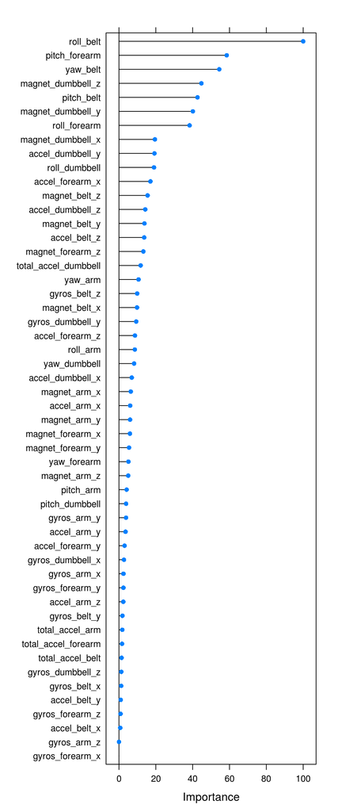

```r
plot(varImp(rffit, top=20))
```

#### Confusion Matrix

```r
rf.pred = predict(rffit, testing)
confusionMatrix(rf.pred, testing$classe)
```

```
## Confusion Matrix and Statistics
##
##           Reference
## Prediction    A    B    C    D    E
##          A 1045    6    0    0    0
##          B    0  706    9    1    1
##          C    0    0  628    6    5
##          D    0    0    4  595    4
##          E    1    0    0    1  666
##
## Overall Statistics
##
##                Accuracy : 0.9897
##                  95% CI : (0.9858, 0.9927)
##     No Information Rate : 0.2844
##     P-Value [Acc > NIR] : < 2.2e-16
##
##                   Kappa : 0.9869
##  Mcnemar's Test P-Value : NA
##
## Statistics by Class:
##
##                      Class: A Class: B Class: C Class: D Class: E
## Sensitivity            0.9990   0.9916   0.9797   0.9867   0.9852
## Specificity            0.9977   0.9963   0.9964   0.9974   0.9993
## Pos Pred Value         0.9943   0.9847   0.9828   0.9867   0.9970
## Neg Pred Value         0.9996   0.9980   0.9957   0.9974   0.9967
## Prevalence             0.2844   0.1936   0.1743   0.1639   0.1838
## Detection Rate         0.2841   0.1920   0.1707   0.1618   0.1811
## Detection Prevalence   0.2858   0.1949   0.1737   0.1639   0.1816
## Balanced Accuracy      0.9984   0.9939   0.9880   0.9921   0.9923
```

### 3. Stochastic gradient boosting (GBM)

```r
library(doMC)                                             # multi-core processing
registerDoMC(cores = 6)

set.seed(1234)
gbmfit = train(classe ~ ., data = training, method = "gbm", trControl = ctrl)
```

#### Contributing vars

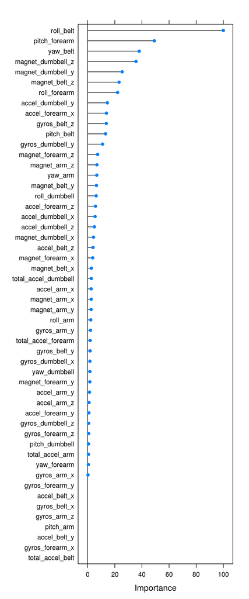

```r
plot(varImp(gbmfit, top=20))
```

#### Confusion Matrix

```r
gbm.pred = predict(gbmfit, testing)
confusionMatrix(gbm.pred, testing$classe)
```

```
## Confusion Matrix and Statistics
##
##           Reference
## Prediction    A    B    C    D    E
##          A 1033   23    0    0    1
##          B   10  669   24    1    5
##          C    1   19  609   19    6
##          D    2    1    7  580   13
##          E    0    0    1    3  651
##
## Overall Statistics
##
##                Accuracy : 0.963
##                  95% CI : (0.9564, 0.9689)
##     No Information Rate : 0.2844
##     P-Value [Acc > NIR] : < 2.2e-16
##
##                   Kappa : 0.9532
##  Mcnemar's Test P-Value : 0.0008367
##
## Statistics by Class:
##
##                      Class: A Class: B Class: C Class: D Class: E
## Sensitivity            0.9876   0.9396   0.9501   0.9619   0.9630
## Specificity            0.9909   0.9865   0.9852   0.9925   0.9987
## Pos Pred Value         0.9773   0.9436   0.9312   0.9619   0.9939
## Neg Pred Value         0.9950   0.9855   0.9894   0.9925   0.9917
## Prevalence             0.2844   0.1936   0.1743   0.1639   0.1838
## Detection Rate         0.2809   0.1819   0.1656   0.1577   0.1770
## Detection Prevalence   0.2874   0.1928   0.1778   0.1639   0.1781
## Balanced Accuracy      0.9892   0.9631   0.9676   0.9772   0.9808
```

### 4. Model ensembling

```r
library(doMC)                                             # multi-core processing
registerDoMC(cores = 6)

set.seed(1234)

mod1 = rffit
mod2 = gbmfit

# Train the ensemble
p1       = rf.pred
p2       = gbm.pred
comboDF  = data.frame(p1, p2, classe = testing$classe)
combofit = train(classe ~ ., data = comboDF, method = "rf")
```

#### Confusion Matrix

```r
# Predict the validation set using 2 models
val.p1          = predict(mod1, val)
val.p2          = predict(mod2, val)
valcombo        = data.frame(val.p1, val.p2, classe = val$classe)
names(valcombo) = names(comboDF)
val.p3          = predict(combofit, valcombo)



confusionMatrix(val.p3, val$classe)
```

```
## Confusion Matrix and Statistics
##
##           Reference
## Prediction    A    B    C    D    E
##          A 1394    6    0    0    0
##          B    1  941    9    0    1
##          C    0    2  844   14    0
##          D    0    0    2  788    3
##          E    0    0    0    2  897
##
## Overall Statistics
##
##                Accuracy : 0.9918
##                  95% CI : (0.9889, 0.9942)
##     No Information Rate : 0.2845
##     P-Value [Acc > NIR] : < 2.2e-16
##
##                   Kappa : 0.9897
##  Mcnemar's Test P-Value : NA
##
## Statistics by Class:
##
##                      Class: A Class: B Class: C Class: D Class: E
## Sensitivity            0.9993   0.9916   0.9871   0.9801   0.9956
## Specificity            0.9983   0.9972   0.9960   0.9988   0.9995
## Pos Pred Value         0.9957   0.9884   0.9814   0.9937   0.9978
## Neg Pred Value         0.9997   0.9980   0.9973   0.9961   0.9990
## Prevalence             0.2845   0.1935   0.1743   0.1639   0.1837
## Detection Rate         0.2843   0.1919   0.1721   0.1607   0.1829
## Detection Prevalence   0.2855   0.1941   0.1754   0.1617   0.1833
## Balanced Accuracy      0.9988   0.9944   0.9916   0.9894   0.9975
```

## Model selection

### Accuracy and Out-of-sample error (OOSE)

```r
library(knitr)
library(ggplot2)

tab = read.csv("selectmodel.csv", header = T)
tab = tab[order(tab$OOSE),]
rownames(tab) = c(1:4)
kable(tab, format = "markdown")
```

| Model | Accuracy | OOSE |
| --- | --- | --- |
| Ensemble | 0.9918 | 0.0082 |
| RF | 0.9897 | 0.0103 |
| GBM | 0.9630 | 0.0370 |
| Rpart | 0.5450 | 0.4550 |

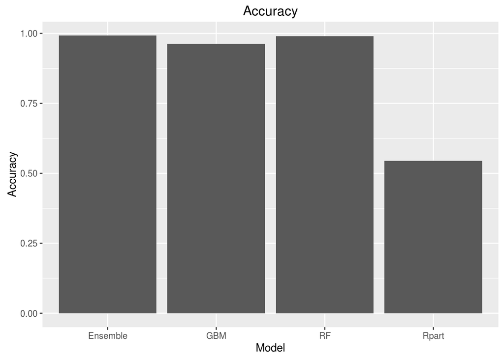

```r
ggplot(tab, aes(Model, Accuracy))+
  geom_bar(stat="identity")+
  ggtitle("Accuracy")
```

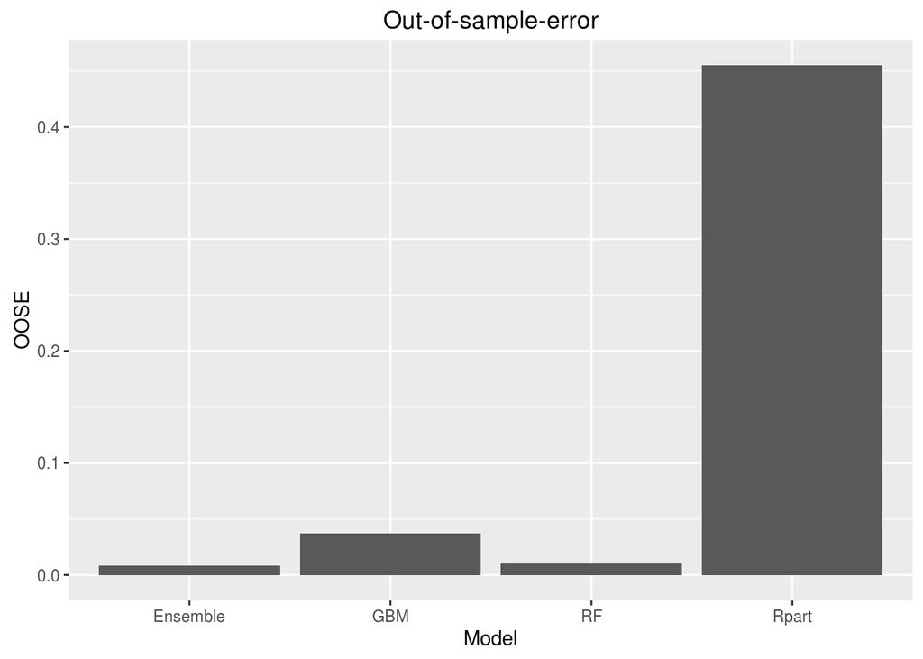

```r
ggplot(tab, aes(Model, OOSE))+
  geom_bar(stat="identity")+
  ggtitle("Out-of-sample-error")
```

## Conclusion

> This shows that the ensemble of the random forests and GBM has the highest accuracy and the lowest out-of-sample error.

## Prediction of the unknown dataset

```r
pred1 = predict(rffit, unk)
pred2 = predict(gbmfit, unk)
combo = data.frame(p1 = pred1, p2 = pred2)
pred  = predict(combofit, combo)

predtab = data.frame(Problem_Id = unk$problem_id, pred = pred)
#predtab
```